# 3D CNN for COPD classification

Within this file several 3D-CNN architectures are set, with the 5 best hyperparameters for 2 layer 3D-CNN and 4 layer 3D-CNN.

The first steps (loading and preprocessing and building train validation datasets) are the same for all the models. First of all we need to import all the necessary libraries to build a CNN 3D. In our CNN we are going to use KERAS.

```python
 # !pip3 install tensorflow
import os
import zipfile
import numpy as np
import tensorflow as tf

from tensorflow import keras
from tensorflow.keras import layers
```

[output not shown]

```python
url = "http://10.20.30.71:8789/user/lmatamala/tree/data_30_samples"
filename = os.path.join(os.getcwd(), "data_30_samples")
keras.utils.get_file(filename, url)
```

```
'/home/lmatamala/data_30_samples'
```

## Loading data and preprocessing

The initial step in our workflow involves the loading of the data and CT images from our dataset into the JupyterHub environment. These files are stored in the **NIfTI format**, denoted by the .nii extension. To facilitate the reading and processing of these scans, we rely on the nibabel package, which provides a robust framework for working with NIfTI files.

CT scans, as a fundamental component of our dataset, employ Hounsfield units (HU) to quantify voxel intensity. HU values play a crucial role in characterizing radiodensity, enabling radiologists and medical professionals to interpret images and diagnose diseases across various medical specialties. This quantifiable scale serves as a reliable reference for understanding tissue composition and pathologies within the scanned anatomical regions.

In our specific dataset, the HU values span a range from -1024 to values exceeding 2000. However, it is important to establish an upper bound to ensure effective normalization. Values above 400 typically correspond to bones with varying radiointensity, thus serving as a practical upper threshold.

To achieve the normalization of CT scans, a commonly employed approach involves applying a threshold within the range of -1000 to 400. This range serves as a reference to rescale the HU values and facilitate consistent comparisons and analysis across the dataset. To process the data, we do the following:

- We first rotate the volumes by 90 degrees, so the orientation is fixed
- We scale the HU values to be between 0 and 1.
- We resize width, height and depth.

Here we define several helper functions to process the data. These functions will be used when building training and validation datasets.

```python
import nibabel as nib

from scipy import ndimage


def read_nifti_file(filepath):
    """Read and load volume"""
    # Read file
    scan = nib.load(filepath)
    # Get raw data
    scan = scan.get_fdata()
    return scan


def normalize(volume):
    """Normalize the volume"""
    min = -1000
    max = 400
    volume[volume < min] = min
    volume[volume > max] = max
    volume = (volume - min) / (max - min)
    volume = volume.astype("float32")
    return volume


def resize_volume(img):
    """Resize across z-axis"""
    # Set the desired depth
    desired_depth = 64
    desired_width = 128
    desired_height = 128
    # Get current depth
    current_depth = img.shape[-1]
    current_width = img.shape[0]
    current_height = img.shape[1]
    # Compute depth factor
    depth = current_depth / desired_depth
    width = current_width / desired_width
    height = current_height / desired_height
    depth_factor = 1 / depth
    width_factor = 1 / width
    height_factor = 1 / height
    # Rotate
    img = ndimage.rotate(img, 90, reshape=False)
    # Resize across z-axis
    img = ndimage.zoom(img, (width_factor, height_factor, depth_factor), order=1)
    return img


def process_scan(path):
    """Read and resize volume"""
    # Read scan
    volume = read_nifti_file(path)
    # Normalize
    volume = normalize(volume)
    # Resize width, height and depth
    volume = resize_volume(volume)
    return volume
```

Now we're going to read the paths of the CT scans from the class directories. A .txt file will give us the information for the classification of the scans.

```python
CT_scan_paths = [
    os.path.join(os.getcwd(), "data_30_samples", x)
    for x in os.listdir("data_30_samples")
]

print("The total number of CT scans that we have right now is: " + str(len(CT_scan_paths)-1))
```

```
The total number of CT scans that we have right now is: 54
```

This next step will help us visualize with a dataframe the medical file where the it shows the classification between COPD patients and Non-smoker controls by the patients id number.

```python
import pandas as pd

data = pd.read_csv('data_30_samples/eclipse_30_samples_no_mask.txt', sep="\t", header=0)
data.columns = ["id", "TRTGRP"]
df = pd.DataFrame(data)
df
```

|  | id | TRTGRP |
| --- | --- | --- |
| 0 | 23140000001 | Non-smoker Controls |
| 1 | 23140000002 | Non-smoker Controls |
| 2 | 23140000003 | Non-smoker Controls |
| 3 | 23140000004 | Non-smoker Controls |
| 4 | 23140000005 | COPD Subjects |
| 5 | 23140000006 | COPD Subjects |
| 6 | 23140000007 | COPD Subjects |
| 7 | 23140000008 | COPD Subjects |
| 8 | 23140000009 | COPD Subjects |
| 9 | 23140000010 | COPD Subjects |
| 10 | 23140000011 | COPD Subjects |
| 11 | 23140000012 | COPD Subjects |
| 12 | 23140000013 | COPD Subjects |
| 13 | 23140000014 | COPD Subjects |
| 14 | 23140000015 | COPD Subjects |
| 15 | 23140000017 | COPD Subjects |
| 16 | 23140000018 | COPD Subjects |
| 17 | 23140000021 | COPD Subjects |
| 18 | 23140000022 | COPD Subjects |
| 19 | 23140000023 | COPD Subjects |
| 20 | 23140000025 | COPD Subjects |
| 21 | 23140000026 | COPD Subjects |
| 22 | 23140000027 | COPD Subjects |
| 23 | 23140000028 | COPD Subjects |
| 24 | 23140000029 | COPD Subjects |
| 25 | 23140000030 | COPD Subjects |
| 26 | 23140000031 | COPD Subjects |
| 27 | 23140000032 | COPD Subjects |
| 28 | 23146000102 | COPD Subjects |
| 29 | 23140000001 | Non-smoker Controls |
| 30 | 23140000002 | Non-smoker Controls |
| 31 | 23140000003 | Non-smoker Controls |
| 32 | 23140000004 | Non-smoker Controls |
| 33 | 23146000087 | Non-smoker Controls |
| 34 | 23147000143 | Non-smoker Controls |
| 35 | 23148000214 | Non-smoker Controls |
| 36 | 23148000229 | Non-smoker Controls |
| 37 | 23148000230 | Non-smoker Controls |
| 38 | 23148000234 | Non-smoker Controls |
| 39 | 23148000254 | Non-smoker Controls |
| 40 | 23148000257 | Non-smoker Controls |
| 41 | 23149000293 | Non-smoker Controls |
| 42 | 23149000299 | Non-smoker Controls |
| 43 | 23150000358 | Non-smoker Controls |
| 44 | 23150000369 | Non-smoker Controls |
| 45 | 23354000421 | Non-smoker Controls |
| 46 | 23354000425 | Non-smoker Controls |
| 47 | 23354000447 | Non-smoker Controls |
| 48 | 23355000510 | Non-smoker Controls |
| 49 | 23356000573 | Non-smoker Controls |
| 50 | 23356000574 | Non-smoker Controls |
| 51 | 23356000591 | Non-smoker Controls |
| 52 | 23356000594 | Non-smoker Controls |
| 53 | 23357000631 | Non-smoker Controls |
| 54 | 23358000716 | Non-smoker Controls |
| 55 | 23358000720 | Non-smoker Controls |
| 56 | 23358000734 | Non-smoker Controls |
| 57 | 23358000738 | Non-smoker Controls |
| 58 | 23358000739 | Non-smoker Controls |

Next we're going to separate the images in two different folders (COPD and Non-smokers)

```python
import os
import shutil
import nibabel as nib
import numpy as np

# Replace these paths with your actual paths
input_folder = 'data_30_samples'
classification_file = 'data_30_samples/eclipse_30_samples_no_mask.txt'
COPD_folder = 'Classification/COPD'
Nonsmoker_folder = 'Classification/Nonsmoker'

# Create cases and controls folders if they don't exist
os.makedirs(COPD_folder, exist_ok=True)
os.makedirs(Nonsmoker_folder, exist_ok=True)

# Read the classification file and create a dictionary with the image identifier as key and classification as value
classification_dict = {}
with open(classification_file, 'r') as file:
    for line in file:
        line_parts = line.strip().split()
        if len(line_parts) >= 2:
            img_identifier, classification = line_parts[:2]
            classification_dict[img_identifier] = classification

# Iterate through all NIFTI files in the input folder
for file_name in os.listdir(input_folder):
    if file_name.endswith('.nii') or file_name.endswith('.nii.gz'):
        # Read image
        img_path = os.path.join(input_folder, file_name)
        img = nib.load(img_path)

        # Get the first 12 characters of the image file name
        file_identifier = file_name[:12]

        # Get classification and move the image to the corresponding folder
        classification = classification_dict.get(file_identifier)
        if classification == 'COPD':
            shutil.copy(img_path, os.path.join(COPD_folder, file_name))
        elif classification == 'Non-smoker':
            shutil.copy(img_path, os.path.join(Nonsmoker_folder, file_name))
        else:
            print(f"Warning: {file_name} not found in classification file.")
```

## Build train and validation datasets

Read the scans from the class directories and assign labels. Downsample the scans to have shape of 128x128x64. Rescale the raw HU values to the range 0 to 1. Lastly, split the dataset into train and validation subsets.

```python
COPD_scan_paths = [
    os.path.join(os.getcwd(), "Classification/COPD", x)
    for x in os.listdir("Classification/COPD")
]
Nonsmoker_scan_paths = [
    os.path.join(os.getcwd(), "Classification/Nonsmoker", x)
    for x in os.listdir("Classification/Nonsmoker")
]

print("CT scans for COPD patients: " + str(len(COPD_scan_paths)))
print("CT scans for Non-smoker control patients: " + str(len(Nonsmoker_scan_paths)))
```

```
CT scans for COPD patients: 25
CT scans for Non-smoker control patients: 28
```

```python
from sklearn.model_selection import train_test_split
import keras.utils
from keras.utils import to_categorical
```

```python
# Read and process the scans.
# Each scan is resized across height, width, and depth and rescaled.
Nonsmoker_scans = np.array([process_scan(path) for path in Nonsmoker_scan_paths])
COPD_scans = np.array([process_scan(path) for path in COPD_scan_paths])

# assign 1 for Non-smoker subjects control scans, and COPD subjects assign 0.
Nonsmoker_labels = np.array([1 for _ in range(len(Nonsmoker_scans))])
COPD_labels = np.array([0 for _ in range(len(COPD_scans))])

image = np.concatenate((Nonsmoker_scans, COPD_scans), axis=0)
labels = np.concatenate((Nonsmoker_labels, COPD_labels), axis=0)

x_train, x_test_val, y_train, y_test_val = train_test_split(image, labels, test_size=0.3, random_state=42)
x_val, x_test, y_val, y_test = train_test_split(x_test_val, y_test_val, test_size=0.33, random_state=42)

y_train = to_categorical(y_train, num_classes=2)
y_val = to_categorical(y_val, num_classes=2)

print(
    "Number of samples in train is %d, for test is %d and for validation is %d."
    % (x_train.shape[0], x_test.shape[0], x_val.shape[0])
)
```

```
Number of samples in train is 37, for test is 6 and for validation is 10.
```

# Different model architectures

## Model 1

- Number of layers: 4
- Units: 512
- Batch size: 16
- Epochs: 100
- Activation function: relu
- Optimizer: Adam

### Data augmentation

The CT scans also augmented by rotating at random angles during training. Since the data is stored in rank-3 tensors of shape (samples, height, width, depth), we add a dimension of size 1 at axis 4 to be able to perform 3D convolutions on the data.

The new shape is thus (samples, height, width, depth, 1). There are different kinds of preprocessing and augmentation techniques out there, this example shows a few simple ones to get started.

```python
import random

from scipy import ndimage


@tf.function
def rotate(volume):
    """Rotate the volume by a few degrees"""

    def scipy_rotate(volume):
        # define some rotation angles
        angles = [-20, -10, -5, 5, 10, 20]
        # pick angles at random
        angle = random.choice(angles)
        # rotate volume
        volume = ndimage.rotate(volume, angle, reshape=False)
        volume[volume < 0] = 0
        volume[volume > 1] = 1
        return volume

    augmented_volume = tf.numpy_function(scipy_rotate, [volume], tf.float32)
    return augmented_volume


def train_preprocessing(volume, label):
    """Process training data by rotating and adding a channel."""
    # Rotate volume
    volume = rotate(volume)
    volume = tf.expand_dims(volume, axis=3)
    return volume, label


def validation_preprocessing(volume, label):
    """Process validation data by only adding a channel."""
    volume = tf.expand_dims(volume, axis=3)
    return volume, label

def test_preprocessing(volume, label):
    """Process test data by only adding a channel."""
    volume = tf.expand_dims(volume, axis=3)
    return volume, label
```

While defining the train and validation data loader, the training data is passed through and augmentation function which randomly rotates volume at different angles. Note that both training and validation data are already rescaled to have values between 0 and 1.

```python
# Define data loaders.
train_loader = tf.data.Dataset.from_tensor_slices((x_train, y_train))
validation_loader = tf.data.Dataset.from_tensor_slices((x_val, y_val))
test_loader = tf.data.Dataset.from_tensor_slices((x_test, y_test))

batch_size = 16
# Augment the on the fly during training.
train_dataset = (
    train_loader.shuffle(len(x_train))
    .map(train_preprocessing)
    .batch(batch_size)
    .prefetch(2)
)
# Only rescale.
validation_dataset = (
    validation_loader.shuffle(len(x_val))
    .map(validation_preprocessing)
    .batch(batch_size)
    .prefetch(2)
)
# Same as validation_dataset basically
test_dataset = (
    test_loader.shuffle(len(x_test))
    .map(test_preprocessing)
    .batch(batch_size)
    .prefetch(2)
)
```

[output not shown]

[output not shown]

### Define the model

```python
def get_model(width=128, height=128, depth=64, num_layers=4):
    """Build a 3D convolutional neural network model."""
    layer_configs = [
        {'filters': 64, 'kernel_size': 3, 'activation': 'relu', 'pool_size': 2},
        {'filters': 64, 'kernel_size': 3, 'activation': 'relu', 'pool_size': 2},
        {'filters': 128, 'kernel_size': 3, 'activation': 'relu', 'pool_size': 2},
        {'filters': 256, 'kernel_size': 3, 'activation': 'relu', 'pool_size': 2},
    ]
    inputs = keras.Input((width, height, depth, 1))
    x = inputs
    for i in range(num_layers):
        x = layers.Conv3D(filters=layer_configs[i]['filters'], kernel_size=layer_configs[i]['kernel_size'], activation=layer_configs[i]['activation'])(x)
        x = layers.MaxPool3D(pool_size=layer_configs[i]['pool_size'])(x)
        x = layers.BatchNormalization()(x)
    x = layers.GlobalAveragePooling3D()(x)
    x = layers.Dense(units=512, activation="relu")(x)
    x = layers.Dropout(0.3)(x)
    outputs = layers.Dense(units=2, activation="sigmoid")(x)
    # Define the model.
    model = keras.Model(inputs, outputs, name="3dcnn")
    return model


# Build model.
model = get_model(width=128, height=128, depth=64)
model.summary()
```

```
Model: "3dcnn"
_________________________________________________________________
 Layer (type)                Output Shape              Param #
=================================================================
 input_1 (InputLayer)        [(None, 128, 128, 64, 1)  0
                             ]

 conv3d (Conv3D)             (None, 126, 126, 62, 64)  1792

 max_pooling3d (MaxPooling3D  (None, 63, 63, 31, 64)   0
 )

 batch_normalization (BatchN  (None, 63, 63, 31, 64)   256
 ormalization)

 conv3d_1 (Conv3D)           (None, 61, 61, 29, 64)    110656

 max_pooling3d_1 (MaxPooling  (None, 30, 30, 14, 64)   0
 3D)

 batch_normalization_1 (Batc  (None, 30, 30, 14, 64)   256
 hNormalization)

 conv3d_2 (Conv3D)           (None, 28, 28, 12, 128)   221312

 max_pooling3d_2 (MaxPooling  (None, 14, 14, 6, 128)   0
 3D)

 batch_normalization_2 (Batc  (None, 14, 14, 6, 128)   512
 hNormalization)

 conv3d_3 (Conv3D)           (None, 12, 12, 4, 256)    884992

 max_pooling3d_3 (MaxPooling  (None, 6, 6, 2, 256)     0
 3D)

 batch_normalization_3 (Batc  (None, 6, 6, 2, 256)     1024
 hNormalization)

 global_average_pooling3d (G  (None, 256)              0
 lobalAveragePooling3D)

 dense (Dense)               (None, 512)               131584

 dropout (Dropout)           (None, 512)               0

 dense_1 (Dense)             (None, 2)                 1026

=================================================================
Total params: 1,353,410
Trainable params: 1,352,386
Non-trainable params: 1,024
_________________________________________________________________
```

### Train the model

```python
from tensorflow import keras
from tensorflow.keras import optimizers
from tensorflow.keras.optimizers import schedules

# Compile model.
initial_learning_rate = 0.0001
lr_schedule = keras.optimizers.schedules.ExponentialDecay(
    initial_learning_rate, decay_steps=100000, decay_rate=0.96, staircase=True
)
model.compile(
    loss="binary_crossentropy",
    optimizer=keras.optimizers.Adam(learning_rate=lr_schedule),
    metrics=["acc"],
)

# Define callbacks.
checkpoint_cb = keras.callbacks.ModelCheckpoint(
    "3d_image_classification.h5", save_best_only=True
)
early_stopping_cb = keras.callbacks.EarlyStopping(monitor="val_acc", patience=15)

# Train the model, doing validation at the end of each epoch
epochs = 100
history = model.fit(
    train_dataset,
    validation_data=validation_dataset,
    epochs=epochs,
    shuffle=True,
    verbose=2,
    callbacks=[checkpoint_cb, early_stopping_cb],
)
```

```
3/3 - 10s - loss: 0.3720 - acc: 0.8919 - val_loss: 0.6740 - val_acc: 0.6000 - 10s/epoch - 3s/step
3/3 - 9s - loss: 0.3132 - acc: 0.9459 - val_loss: 0.6751 - val_acc: 0.6000 - 9s/epoch - 3s/step
3/3 - 9s - loss: 0.2537 - acc: 0.9730 - val_loss: 0.6747 - val_acc: 0.6000 - 9s/epoch - 3s/step
3/3 - 9s - loss: 0.2569 - acc: 0.8919 - val_loss: 0.6752 - val_acc: 0.6000 - 9s/epoch - 3s/step
3/3 - 9s - loss: 0.2179 - acc: 0.9459 - val_loss: 0.6788 - val_acc: 0.6000 - 9s/epoch - 3s/step
3/3 - 8s - loss: 0.1723 - acc: 0.9730 - val_loss: 0.6793 - val_acc: 0.6000 - 8s/epoch - 3s/step
3/3 - 9s - loss: 0.1845 - acc: 0.9189 - val_loss: 0.6870 - val_acc: 0.6000 - 9s/epoch - 3s/step
3/3 - 9s - loss: 0.1458 - acc: 1.0000 - val_loss: 0.7088 - val_acc: 0.4000 - 9s/epoch - 3s/step
3/3 - 9s - loss: 0.1904 - acc: 0.9459 - val_loss: 0.7160 - val_acc: 0.4000 - 9s/epoch - 3s/step
3/3 - 9s - loss: 0.1156 - acc: 1.0000 - val_loss: 0.7365 - val_acc: 0.4000 - 9s/epoch - 3s/step
3/3 - 9s - loss: 0.1579 - acc: 0.9459 - val_loss: 0.7711 - val_acc: 0.4000 - 9s/epoch - 3s/step
3/3 - 9s - loss: 0.1105 - acc: 0.9730 - val_loss: 0.7139 - val_acc: 0.4000 - 9s/epoch - 3s/step
3/3 - 9s - loss: 0.0994 - acc: 0.9730 - val_loss: 0.6980 - val_acc: 0.4000 - 9s/epoch - 3s/step
3/3 - 9s - loss: 0.1582 - acc: 0.9189 - val_loss: 0.7175 - val_acc: 0.4000 - 9s/epoch - 3s/step
3/3 - 8s - loss: 0.1310 - acc: 0.9730 - val_loss: 0.7535 - val_acc: 0.4000 - 8s/epoch - 3s/step
3/3 - 9s - loss: 0.1200 - acc: 1.0000 - val_loss: 0.7486 - val_acc: 0.4000 - 9s/epoch - 3s/step
```

### Visualizing model performance

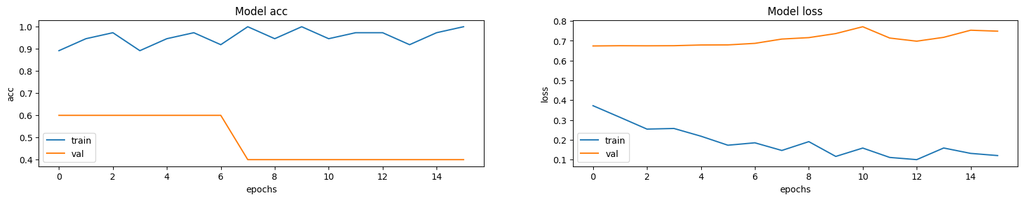

```python
fig, ax = plt.subplots(1, 2, figsize=(20, 3))
ax = ax.ravel()

for i, metric in enumerate(["acc", "loss"]):
    ax[i].plot(model.history.history[metric])
    ax[i].plot(model.history.history["val_" + metric])
    ax[i].set_title("Model {}".format(metric))
    ax[i].set_xlabel("epochs")
    ax[i].set_ylabel(metric)
    ax[i].legend(["train", "val"])
```

```python
results = model.evaluate(validation_dataset, batch_size=8)
print("test loss, test acc:", results)
```

[output not shown]

### Making predictions on a single CT scan

```python
# Load best weights.
model.load_weights("3d_image_classification.h5")
prediction = model.predict(np.expand_dims(x_val[0], axis=0))[0]
scores = [1 - prediction[0], prediction[0]]

class_names = ["COPD", "Non-smoker control"]
for score, name in zip(scores, class_names):
    print(
        "This model is %.2f percent confident that CT scan is %s"
        % ((100 * score), name)
    )
```

```
This model is 56.06 percent confident that CT scan is COPD
This model is 43.94 percent confident that CT scan is Non-smoker control
```

## Model 2

- Number of layers: 4
- Units: 256
- Batch size: 16
- Epochs: 50
- Activation function: relu
- Optimizer: Adam

```python
# Data augmentation
import random

from scipy import ndimage


@tf.function
def rotate(volume):
    """Rotate the volume by a few degrees"""

    def scipy_rotate(volume):
        # define some rotation angles
        angles = [-20, -10, -5, 5, 10, 20]
        # pick angles at random
        angle = random.choice(angles)
        # rotate volume
        volume = ndimage.rotate(volume, angle, reshape=False)
        volume[volume < 0] = 0
        volume[volume > 1] = 1
        return volume

    augmented_volume = tf.numpy_function(scipy_rotate, [volume], tf.float32)
    return augmented_volume


def train_preprocessing(volume, label):
    """Process training data by rotating and adding a channel."""
    # Rotate volume
    volume = rotate(volume)
    volume = tf.expand_dims(volume, axis=3)
    return volume, label


def validation_preprocessing(volume, label):
    """Process validation data by only adding a channel."""
    volume = tf.expand_dims(volume, axis=3)
    return volume, label

def test_preprocessing(volume, label):
    """Process test data by only adding a channel."""
    volume = tf.expand_dims(volume, axis=3)
    return volume, label
```

```python
# Define data loaders.
train_loader = tf.data.Dataset.from_tensor_slices((x_train, y_train))
validation_loader = tf.data.Dataset.from_tensor_slices((x_val, y_val))
test_loader = tf.data.Dataset.from_tensor_slices((x_test, y_test))

batch_size = 16
# Augment the on the fly during training.
train_dataset = (
    train_loader.shuffle(len(x_train))
    .map(train_preprocessing)
    .batch(batch_size)
    .prefetch(2)
)
# Only rescale.
validation_dataset = (
    validation_loader.shuffle(len(x_val))
    .map(validation_preprocessing)
    .batch(batch_size)
    .prefetch(2)
)
# Same as validation_dataset basically
test_dataset = (
    test_loader.shuffle(len(x_test))
    .map(test_preprocessing)
    .batch(batch_size)
    .prefetch(2)
)
```

```python
# Define the model
def get_model(width=128, height=128, depth=64, num_layers=4):
    """Build a 3D convolutional neural network model."""
    layer_configs = [
        {'filters': 64, 'kernel_size': 3, 'activation': 'relu', 'pool_size': 2},
        {'filters': 64, 'kernel_size': 3, 'activation': 'relu', 'pool_size': 2},
        {'filters': 128, 'kernel_size': 3, 'activation': 'relu', 'pool_size': 2},
        {'filters': 256, 'kernel_size': 3, 'activation': 'relu', 'pool_size': 2},
    ]
    inputs = keras.Input((width, height, depth, 1))
    x = inputs
    for i in range(num_layers):
        x = layers.Conv3D(filters=layer_configs[i]['filters'], kernel_size=layer_configs[i]['kernel_size'], activation=layer_configs[i]['activation'])(x)
        x = layers.MaxPool3D(pool_size=layer_configs[i]['pool_size'])(x)
        x = layers.BatchNormalization()(x)
    x = layers.GlobalAveragePooling3D()(x)
    x = layers.Dense(units=256, activation="relu")(x)
    x = layers.Dropout(0.3)(x)
    outputs = layers.Dense(units=2, activation="sigmoid")(x)
    # Define the model.
    model = keras.Model(inputs, outputs, name="3dcnn")
    return model


# Build model.
model = get_model(width=128, height=128, depth=64)
model.summary()
```

```python
# Train model

from tensorflow import keras
from tensorflow.keras import optimizers
from tensorflow.keras.optimizers import schedules

# Compile model.
initial_learning_rate = 0.0001
lr_schedule = keras.optimizers.schedules.ExponentialDecay(
    initial_learning_rate, decay_steps=100000, decay_rate=0.96, staircase=True
)
model.compile(
    loss="binary_crossentropy",
    optimizer=keras.optimizers.Adam(learning_rate=lr_schedule),
    metrics=["acc"],
)

# Define callbacks.
checkpoint_cb = keras.callbacks.ModelCheckpoint(
    "3d_image_classification.h5", save_best_only=True
)
early_stopping_cb = keras.callbacks.EarlyStopping(monitor="val_acc", patience=15)

# Train the model, doing validation at the end of each epoch
epochs = 50
history = model.fit(
    train_dataset,
    validation_data=validation_dataset,
    epochs=epochs,
    shuffle=True,
    verbose=2,
    callbacks=[checkpoint_cb, early_stopping_cb],
)
```

```python
# Visualizing model performance
fig, ax = plt.subplots(1, 2, figsize=(20, 3))
ax = ax.ravel()

for i, metric in enumerate(["acc", "loss"]):
    ax[i].plot(model.history.history[metric])
    ax[i].plot(model.history.history["val_" + metric])
    ax[i].set_title("Model {}".format(metric))
    ax[i].set_xlabel("epochs")
    ax[i].set_ylabel(metric)
    ax[i].legend(["train", "val"])
```

```python
results = model.evaluate(validation_dataset, batch_size=8)
print("test loss, test acc:", results)
```

## Model 3

- Number of layers: 4
- Units: 256
- Batch size: 32
- Epochs: 100
- Activation function: relu
- Optimizer: Adam

```python
# Data augmentation
import random

from scipy import ndimage


@tf.function
def rotate(volume):
    """Rotate the volume by a few degrees"""

    def scipy_rotate(volume):
        # define some rotation angles
        angles = [-20, -10, -5, 5, 10, 20]
        # pick angles at random
        angle = random.choice(angles)
        # rotate volume
        volume = ndimage.rotate(volume, angle, reshape=False)
        volume[volume < 0] = 0
        volume[volume > 1] = 1
        return volume

    augmented_volume = tf.numpy_function(scipy_rotate, [volume], tf.float32)
    return augmented_volume


def train_preprocessing(volume, label):
    """Process training data by rotating and adding a channel."""
    # Rotate volume
    volume = rotate(volume)
    volume = tf.expand_dims(volume, axis=3)
    return volume, label


def validation_preprocessing(volume, label):
    """Process validation data by only adding a channel."""
    volume = tf.expand_dims(volume, axis=3)
    return volume, label

def test_preprocessing(volume, label):
    """Process test data by only adding a channel."""
    volume = tf.expand_dims(volume, axis=3)
    return volume, label
```

```python
# Define data loaders.
train_loader = tf.data.Dataset.from_tensor_slices((x_train, y_train))
validation_loader = tf.data.Dataset.from_tensor_slices((x_val, y_val))
test_loader = tf.data.Dataset.from_tensor_slices((x_test, y_test))

batch_size = 32
# Augment the on the fly during training.
train_dataset = (
    train_loader.shuffle(len(x_train))
    .map(train_preprocessing)
    .batch(batch_size)
    .prefetch(2)
)
# Only rescale.
validation_dataset = (
    validation_loader.shuffle(len(x_val))
    .map(validation_preprocessing)
    .batch(batch_size)
    .prefetch(2)
)
# Same as validation_dataset basically
test_dataset = (
    test_loader.shuffle(len(x_test))
    .map(test_preprocessing)
    .batch(batch_size)
    .prefetch(2)
)
```

```python
# Define the model
def get_model(width=128, height=128, depth=64, num_layers=4):
    """Build a 3D convolutional neural network model."""
    layer_configs = [
        {'filters': 64, 'kernel_size': 3, 'activation': 'relu', 'pool_size': 2},
        {'filters': 64, 'kernel_size': 3, 'activation': 'relu', 'pool_size': 2},
        {'filters': 128, 'kernel_size': 3, 'activation': 'relu', 'pool_size': 2},
        {'filters': 256, 'kernel_size': 3, 'activation': 'relu', 'pool_size': 2},
    ]
    inputs = keras.Input((width, height, depth, 1))
    x = inputs
    for i in range(num_layers):
        x = layers.Conv3D(filters=layer_configs[i]['filters'], kernel_size=layer_configs[i]['kernel_size'], activation=layer_configs[i]['activation'])(x)
        x = layers.MaxPool3D(pool_size=layer_configs[i]['pool_size'])(x)
        x = layers.BatchNormalization()(x)
    x = layers.GlobalAveragePooling3D()(x)
    x = layers.Dense(units=256, activation="relu")(x)
    x = layers.Dropout(0.3)(x)
    outputs = layers.Dense(units=2, activation="sigmoid")(x)
    # Define the model.
    model = keras.Model(inputs, outputs, name="3dcnn")
    return model


# Build model.
model = get_model(width=128, height=128, depth=64)
model.summary()
```

```python
# Train model

from tensorflow import keras
from tensorflow.keras import optimizers
from tensorflow.keras.optimizers import schedules

# Compile model.
initial_learning_rate = 0.0001
lr_schedule = keras.optimizers.schedules.ExponentialDecay(
    initial_learning_rate, decay_steps=100000, decay_rate=0.96, staircase=True
)
model.compile(
    loss="binary_crossentropy",
    optimizer=keras.optimizers.Adam(learning_rate=lr_schedule),
    metrics=["acc"],
)

# Define callbacks.
checkpoint_cb = keras.callbacks.ModelCheckpoint(
    "3d_image_classification.h5", save_best_only=True
)
early_stopping_cb = keras.callbacks.EarlyStopping(monitor="val_acc", patience=15)

# Train the model, doing validation at the end of each epoch
epochs = 100
history = model.fit(
    train_dataset,
    validation_data=validation_dataset,
    epochs=epochs,
    shuffle=True,
    verbose=2,
    callbacks=[checkpoint_cb, early_stopping_cb],
)
```

```python
# Visualizing model performance
fig, ax = plt.subplots(1, 2, figsize=(20, 3))
ax = ax.ravel()

for i, metric in enumerate(["acc", "loss"]):
    ax[i].plot(model.history.history[metric])
    ax[i].plot(model.history.history["val_" + metric])
    ax[i].set_title("Model {}".format(metric))
    ax[i].set_xlabel("epochs")
    ax[i].set_ylabel(metric)
    ax[i].legend(["train", "val"])
```

```python
results = model.evaluate(validation_dataset, batch_size=8)
print("test loss, test acc:", results)
```

## Model 4

- Number of layers: 4
- Units: 256
- Batch size: 16
- Epochs: 100
- Activation function: relu
- Optimizer: Adam

```python
# Data augmentation
import random

from scipy import ndimage


@tf.function
def rotate(volume):
    """Rotate the volume by a few degrees"""

    def scipy_rotate(volume):
        # define some rotation angles
        angles = [-20, -10, -5, 5, 10, 20]
        # pick angles at random
        angle = random.choice(angles)
        # rotate volume
        volume = ndimage.rotate(volume, angle, reshape=False)
        volume[volume < 0] = 0
        volume[volume > 1] = 1
        return volume

    augmented_volume = tf.numpy_function(scipy_rotate, [volume], tf.float32)
    return augmented_volume


def train_preprocessing(volume, label):
    """Process training data by rotating and adding a channel."""
    # Rotate volume
    volume = rotate(volume)
    volume = tf.expand_dims(volume, axis=3)
    return volume, label


def validation_preprocessing(volume, label):
    """Process validation data by only adding a channel."""
    volume = tf.expand_dims(volume, axis=3)
    return volume, label

def test_preprocessing(volume, label):
    """Process test data by only adding a channel."""
    volume = tf.expand_dims(volume, axis=3)
    return volume, label
```

```python
# Define data loaders.
train_loader = tf.data.Dataset.from_tensor_slices((x_train, y_train))
validation_loader = tf.data.Dataset.from_tensor_slices((x_val, y_val))
test_loader = tf.data.Dataset.from_tensor_slices((x_test, y_test))

batch_size = 16
# Augment the on the fly during training.
train_dataset = (
    train_loader.shuffle(len(x_train))
    .map(train_preprocessing)
    .batch(batch_size)
    .prefetch(2)
)
# Only rescale.
validation_dataset = (
    validation_loader.shuffle(len(x_val))
    .map(validation_preprocessing)
    .batch(batch_size)
    .prefetch(2)
)
# Same as validation_dataset basically
test_dataset = (
    test_loader.shuffle(len(x_test))
    .map(test_preprocessing)
    .batch(batch_size)
    .prefetch(2)
)
```

```python
# Define the model
def get_model(width=128, height=128, depth=64, num_layers=4):
    """Build a 3D convolutional neural network model."""
    layer_configs = [
        {'filters': 64, 'kernel_size': 3, 'activation': 'relu', 'pool_size': 2},
        {'filters': 64, 'kernel_size': 3, 'activation': 'relu', 'pool_size': 2},
        {'filters': 128, 'kernel_size': 3, 'activation': 'relu', 'pool_size': 2},
        {'filters': 256, 'kernel_size': 3, 'activation': 'relu', 'pool_size': 2},
    ]
    inputs = keras.Input((width, height, depth, 1))
    x = inputs
    for i in range(num_layers):
        x = layers.Conv3D(filters=layer_configs[i]['filters'], kernel_size=layer_configs[i]['kernel_size'], activation=layer_configs[i]['activation'])(x)
        x = layers.MaxPool3D(pool_size=layer_configs[i]['pool_size'])(x)
        x = layers.BatchNormalization()(x)
    x = layers.GlobalAveragePooling3D()(x)
    x = layers.Dense(units=256, activation="relu")(x)
    x = layers.Dropout(0.3)(x)
    outputs = layers.Dense(units=2, activation="sigmoid")(x)
    # Define the model.
    model = keras.Model(inputs, outputs, name="3dcnn")
    return model


# Build model.
model = get_model(width=128, height=128, depth=64)
model.summary()
```

```python
# Train model

from tensorflow import keras
from tensorflow.keras import optimizers
from tensorflow.keras.optimizers import schedules

# Compile model.
initial_learning_rate = 0.0001
lr_schedule = keras.optimizers.schedules.ExponentialDecay(
    initial_learning_rate, decay_steps=100000, decay_rate=0.96, staircase=True
)
model.compile(
    loss="binary_crossentropy",
    optimizer=keras.optimizers.Adam(learning_rate=lr_schedule),
    metrics=["acc"],
)

# Define callbacks.
checkpoint_cb = keras.callbacks.ModelCheckpoint(
    "3d_image_classification.h5", save_best_only=True
)
early_stopping_cb = keras.callbacks.EarlyStopping(monitor="val_acc", patience=15)

# Train the model, doing validation at the end of each epoch
epochs = 100
history = model.fit(
    train_dataset,
    validation_data=validation_dataset,
    epochs=epochs,
    shuffle=True,
    verbose=2,
    callbacks=[checkpoint_cb, early_stopping_cb],
)
```

```python
# Visualizing model performance
fig, ax = plt.subplots(1, 2, figsize=(20, 3))
ax = ax.ravel()

for i, metric in enumerate(["acc", "loss"]):
    ax[i].plot(model.history.history[metric])
    ax[i].plot(model.history.history["val_" + metric])
    ax[i].set_title("Model {}".format(metric))
    ax[i].set_xlabel("epochs")
    ax[i].set_ylabel(metric)
    ax[i].legend(["train", "val"])
```

```python
results = model.evaluate(validation_dataset, batch_size=8)
print("test loss, test acc:", results)
```

## Model 5

- Number of layers: 4
- Units: 512
- Batch size: 32
- Epochs: 100
- Activation function: relu
- Optimizer: Adam

```python
# Data augmentation
import random

from scipy import ndimage


@tf.function
def rotate(volume):
    """Rotate the volume by a few degrees"""

    def scipy_rotate(volume):
        # define some rotation angles
        angles = [-20, -10, -5, 5, 10, 20]
        # pick angles at random
        angle = random.choice(angles)
        # rotate volume
        volume = ndimage.rotate(volume, angle, reshape=False)
        volume[volume < 0] = 0
        volume[volume > 1] = 1
        return volume

    augmented_volume = tf.numpy_function(scipy_rotate, [volume], tf.float32)
    return augmented_volume


def train_preprocessing(volume, label):
    """Process training data by rotating and adding a channel."""
    # Rotate volume
    volume = rotate(volume)
    volume = tf.expand_dims(volume, axis=3)
    return volume, label


def validation_preprocessing(volume, label):
    """Process validation data by only adding a channel."""
    volume = tf.expand_dims(volume, axis=3)
    return volume, label

def test_preprocessing(volume, label):
    """Process test data by only adding a channel."""
    volume = tf.expand_dims(volume, axis=3)
    return volume, label
```

```python
# Define data loaders.
train_loader = tf.data.Dataset.from_tensor_slices((x_train, y_train))
validation_loader = tf.data.Dataset.from_tensor_slices((x_val, y_val))
test_loader = tf.data.Dataset.from_tensor_slices((x_test, y_test))

batch_size = 32
# Augment the on the fly during training.
train_dataset = (
    train_loader.shuffle(len(x_train))
    .map(train_preprocessing)
    .batch(batch_size)
    .prefetch(2)
)
# Only rescale.
validation_dataset = (
    validation_loader.shuffle(len(x_val))
    .map(validation_preprocessing)
    .batch(batch_size)
    .prefetch(2)
)
# Same as validation_dataset basically
test_dataset = (
    test_loader.shuffle(len(x_test))
    .map(test_preprocessing)
    .batch(batch_size)
    .prefetch(2)
)
```

```python
# Define the model
def get_model(width=128, height=128, depth=64, num_layers=4):
    """Build a 3D convolutional neural network model."""
    layer_configs = [
        {'filters': 64, 'kernel_size': 3, 'activation': 'relu', 'pool_size': 2},
        {'filters': 64, 'kernel_size': 3, 'activation': 'relu', 'pool_size': 2},
        {'filters': 128, 'kernel_size': 3, 'activation': 'relu', 'pool_size': 2},
        {'filters': 256, 'kernel_size': 3, 'activation': 'relu', 'pool_size': 2},
    ]
    inputs = keras.Input((width, height, depth, 1))
    x = inputs
    for i in range(num_layers):
        x = layers.Conv3D(filters=layer_configs[i]['filters'], kernel_size=layer_configs[i]['kernel_size'], activation=layer_configs[i]['activation'])(x)
        x = layers.MaxPool3D(pool_size=layer_configs[i]['pool_size'])(x)
        x = layers.BatchNormalization()(x)
    x = layers.GlobalAveragePooling3D()(x)
    x = layers.Dense(units=512, activation="relu")(x)
    x = layers.Dropout(0.3)(x)
    outputs = layers.Dense(units=2, activation="sigmoid")(x)
    # Define the model.
    model = keras.Model(inputs, outputs, name="3dcnn")
    return model


# Build model.
model = get_model(width=128, height=128, depth=64)
model.summary()
```

```python
# Train model

from tensorflow import keras
from tensorflow.keras import optimizers
from tensorflow.keras.optimizers import schedules

# Compile model.
initial_learning_rate = 0.0001
lr_schedule = keras.optimizers.schedules.ExponentialDecay(
    initial_learning_rate, decay_steps=100000, decay_rate=0.96, staircase=True
)
model.compile(
    loss="binary_crossentropy",
    optimizer=keras.optimizers.Adam(learning_rate=lr_schedule),
    metrics=["acc"],
)

# Define callbacks.
checkpoint_cb = keras.callbacks.ModelCheckpoint(
    "3d_image_classification.h5", save_best_only=True
)
early_stopping_cb = keras.callbacks.EarlyStopping(monitor="val_acc", patience=15)

# Train the model, doing validation at the end of each epoch
epochs = 100
history = model.fit(
    train_dataset,
    validation_data=validation_dataset,
    epochs=epochs,
    shuffle=True,
    verbose=2,
    callbacks=[checkpoint_cb, early_stopping_cb],
)
```

```python
# Visualizing model performance
fig, ax = plt.subplots(1, 2, figsize=(20, 3))
ax = ax.ravel()

for i, metric in enumerate(["acc", "loss"]):
    ax[i].plot(model.history.history[metric])
    ax[i].plot(model.history.history["val_" + metric])
    ax[i].set_title("Model {}".format(metric))
    ax[i].set_xlabel("epochs")
    ax[i].set_ylabel(metric)
    ax[i].legend(["train", "val"])
```

```python
results = model.evaluate(validation_dataset, batch_size=8)
print("test loss, test acc:", results)
```

## Model 6

- Number of layers: 2
- Units: 512
- Batch size: 16
- Epochs: 100
- Activation function: relu
- Optimizer: Adam

```python
# Data augmentation
import random

from scipy import ndimage


@tf.function
def rotate(volume):
    """Rotate the volume by a few degrees"""

    def scipy_rotate(volume):
        # define some rotation angles
        angles = [-20, -10, -5, 5, 10, 20]
        # pick angles at random
        angle = random.choice(angles)
        # rotate volume
        volume = ndimage.rotate(volume, angle, reshape=False)
        volume[volume < 0] = 0
        volume[volume > 1] = 1
        return volume

    augmented_volume = tf.numpy_function(scipy_rotate, [volume], tf.float32)
    return augmented_volume


def train_preprocessing(volume, label):
    """Process training data by rotating and adding a channel."""
    # Rotate volume
    volume = rotate(volume)
    volume = tf.expand_dims(volume, axis=3)
    return volume, label


def validation_preprocessing(volume, label):
    """Process validation data by only adding a channel."""
    volume = tf.expand_dims(volume, axis=3)
    return volume, label

def test_preprocessing(volume, label):
    """Process test data by only adding a channel."""
    volume = tf.expand_dims(volume, axis=3)
    return volume, label
```

```python
# Define data loaders.
train_loader = tf.data.Dataset.from_tensor_slices((x_train, y_train))
validation_loader = tf.data.Dataset.from_tensor_slices((x_val, y_val))
test_loader = tf.data.Dataset.from_tensor_slices((x_test, y_test))

batch_size = 16
# Augment the on the fly during training.
train_dataset = (
    train_loader.shuffle(len(x_train))
    .map(train_preprocessing)
    .batch(batch_size)
    .prefetch(2)
)
# Only rescale.
validation_dataset = (
    validation_loader.shuffle(len(x_val))
    .map(validation_preprocessing)
    .batch(batch_size)
    .prefetch(2)
)
# Same as validation_dataset basically
test_dataset = (
    test_loader.shuffle(len(x_test))
    .map(test_preprocessing)
    .batch(batch_size)
    .prefetch(2)
)
```

```python
# Define the model
def get_model(width=128, height=128, depth=64, num_layers=4):
    """Build a 3D convolutional neural network model."""
    layer_configs = [
        {'filters': 64, 'kernel_size': 3, 'activation': 'relu', 'pool_size': 2},
        {'filters': 64, 'kernel_size': 3, 'activation': 'relu', 'pool_size': 2},
    ]
    inputs = keras.Input((width, height, depth, 1))
    x = inputs
    for i in range(num_layers):
        x = layers.Conv3D(filters=layer_configs[i]['filters'], kernel_size=layer_configs[i]['kernel_size'], activation=layer_configs[i]['activation'])(x)
        x = layers.MaxPool3D(pool_size=layer_configs[i]['pool_size'])(x)
        x = layers.BatchNormalization()(x)
    x = layers.GlobalAveragePooling3D()(x)
    x = layers.Dense(units=512, activation="relu")(x)
    x = layers.Dropout(0.3)(x)
    outputs = layers.Dense(units=2, activation="sigmoid")(x)
    # Define the model.
    model = keras.Model(inputs, outputs, name="3dcnn")
    return model


# Build model.
model = get_model(width=128, height=128, depth=64)
model.summary()
```

```python
# Train model

from tensorflow import keras
from tensorflow.keras import optimizers
from tensorflow.keras.optimizers import schedules

# Compile model.
initial_learning_rate = 0.0001
lr_schedule = keras.optimizers.schedules.ExponentialDecay(
    initial_learning_rate, decay_steps=100000, decay_rate=0.96, staircase=True
)
model.compile(
    loss="binary_crossentropy",
    optimizer=keras.optimizers.Adam(learning_rate=lr_schedule),
    metrics=["acc"],
)

# Define callbacks.
checkpoint_cb = keras.callbacks.ModelCheckpoint(
    "3d_image_classification.h5", save_best_only=True
)
early_stopping_cb = keras.callbacks.EarlyStopping(monitor="val_acc", patience=15)

# Train the model, doing validation at the end of each epoch
epochs = 100
history = model.fit(
    train_dataset,
    validation_data=validation_dataset,
    epochs=epochs,
    shuffle=True,
    verbose=2,
    callbacks=[checkpoint_cb, early_stopping_cb],
)
```

```python
# Visualizing model performance
fig, ax = plt.subplots(1, 2, figsize=(20, 3))
ax = ax.ravel()

for i, metric in enumerate(["acc", "loss"]):
    ax[i].plot(model.history.history[metric])
    ax[i].plot(model.history.history["val_" + metric])
    ax[i].set_title("Model {}".format(metric))
    ax[i].set_xlabel("epochs")
    ax[i].set_ylabel(metric)
    ax[i].legend(["train", "val"])
```

```python
results = model.evaluate(validation_dataset, batch_size=8)
print("test loss, test acc:", results)
```

## Model 7

- Number of layers: 2
- Units: 512
- Batch size: 32
- Epochs: 50
- Activation function: relu
- Optimizer: Adam

```python
# Data augmentation
import random

from scipy import ndimage


@tf.function
def rotate(volume):
    """Rotate the volume by a few degrees"""

    def scipy_rotate(volume):
        # define some rotation angles
        angles = [-20, -10, -5, 5, 10, 20]
        # pick angles at random
        angle = random.choice(angles)
        # rotate volume
        volume = ndimage.rotate(volume, angle, reshape=False)
        volume[volume < 0] = 0
        volume[volume > 1] = 1
        return volume

    augmented_volume = tf.numpy_function(scipy_rotate, [volume], tf.float32)
    return augmented_volume


def train_preprocessing(volume, label):
    """Process training data by rotating and adding a channel."""
    # Rotate volume
    volume = rotate(volume)
    volume = tf.expand_dims(volume, axis=3)
    return volume, label


def validation_preprocessing(volume, label):
    """Process validation data by only adding a channel."""
    volume = tf.expand_dims(volume, axis=3)
    return volume, label

def test_preprocessing(volume, label):
    """Process test data by only adding a channel."""
    volume = tf.expand_dims(volume, axis=3)
    return volume, label
```

```python
# Define data loaders.
train_loader = tf.data.Dataset.from_tensor_slices((x_train, y_train))
validation_loader = tf.data.Dataset.from_tensor_slices((x_val, y_val))
test_loader = tf.data.Dataset.from_tensor_slices((x_test, y_test))

batch_size = 32
# Augment the on the fly during training.
train_dataset = (
    train_loader.shuffle(len(x_train))
    .map(train_preprocessing)
    .batch(batch_size)
    .prefetch(2)
)
# Only rescale.
validation_dataset = (
    validation_loader.shuffle(len(x_val))
    .map(validation_preprocessing)
    .batch(batch_size)
    .prefetch(2)
)
# Same as validation_dataset basically
test_dataset = (
    test_loader.shuffle(len(x_test))
    .map(test_preprocessing)
    .batch(batch_size)
    .prefetch(2)
)
```

```python
# Define the model
def get_model(width=128, height=128, depth=64, num_layers=4):
    """Build a 3D convolutional neural network model."""
    layer_configs = [
        {'filters': 64, 'kernel_size': 3, 'activation': 'relu', 'pool_size': 2},
        {'filters': 64, 'kernel_size': 3, 'activation': 'relu', 'pool_size': 2},
    ]
    inputs = keras.Input((width, height, depth, 1))
    x = inputs
    for i in range(num_layers):
        x = layers.Conv3D(filters=layer_configs[i]['filters'], kernel_size=layer_configs[i]['kernel_size'], activation=layer_configs[i]['activation'])(x)
        x = layers.MaxPool3D(pool_size=layer_configs[i]['pool_size'])(x)
        x = layers.BatchNormalization()(x)
    x = layers.GlobalAveragePooling3D()(x)
    x = layers.Dense(units=512, activation="relu")(x)
    x = layers.Dropout(0.3)(x)
    outputs = layers.Dense(units=2, activation="sigmoid")(x)
    # Define the model.
    model = keras.Model(inputs, outputs, name="3dcnn")
    return model


# Build model.
model = get_model(width=128, height=128, depth=64)
model.summary()
```

```python
# Train model

from tensorflow import keras
from tensorflow.keras import optimizers
from tensorflow.keras.optimizers import schedules

# Compile model.
initial_learning_rate = 0.0001
lr_schedule = keras.optimizers.schedules.ExponentialDecay(
    initial_learning_rate, decay_steps=100000, decay_rate=0.96, staircase=True
)
model.compile(
    loss="binary_crossentropy",
    optimizer=keras.optimizers.Adam(learning_rate=lr_schedule),
    metrics=["acc"],
)

# Define callbacks.
checkpoint_cb = keras.callbacks.ModelCheckpoint(
    "3d_image_classification.h5", save_best_only=True
)
early_stopping_cb = keras.callbacks.EarlyStopping(monitor="val_acc", patience=15)

# Train the model, doing validation at the end of each epoch
epochs = 50
history = model.fit(
    train_dataset,
    validation_data=validation_dataset,
    epochs=epochs,
    shuffle=True,
    verbose=2,
    callbacks=[checkpoint_cb, early_stopping_cb],
)
```

```python
# Visualizing model performance
fig, ax = plt.subplots(1, 2, figsize=(20, 3))
ax = ax.ravel()

for i, metric in enumerate(["acc", "loss"]):
    ax[i].plot(model.history.history[metric])
    ax[i].plot(model.history.history["val_" + metric])
    ax[i].set_title("Model {}".format(metric))
    ax[i].set_xlabel("epochs")
    ax[i].set_ylabel(metric)
    ax[i].legend(["train", "val"])
```

```python
results = model.evaluate(validation_dataset, batch_size=8)
print("test loss, test acc:", results)
```

## Model 8

- Number of layers: 2
- Units: 256
- Batch size: 16
- Epochs: 100
- Activation function: relu
- Optimizer: Adam

```python
# Data augmentation
import random

from scipy import ndimage


@tf.function
def rotate(volume):
    """Rotate the volume by a few degrees"""

    def scipy_rotate(volume):
        # define some rotation angles
        angles = [-20, -10, -5, 5, 10, 20]
        # pick angles at random
        angle = random.choice(angles)
        # rotate volume
        volume = ndimage.rotate(volume, angle, reshape=False)
        volume[volume < 0] = 0
        volume[volume > 1] = 1
        return volume

    augmented_volume = tf.numpy_function(scipy_rotate, [volume], tf.float32)
    return augmented_volume


def train_preprocessing(volume, label):
    """Process training data by rotating and adding a channel."""
    # Rotate volume
    volume = rotate(volume)
    volume = tf.expand_dims(volume, axis=3)
    return volume, label


def validation_preprocessing(volume, label):
    """Process validation data by only adding a channel."""
    volume = tf.expand_dims(volume, axis=3)
    return volume, label

def test_preprocessing(volume, label):
    """Process test data by only adding a channel."""
    volume = tf.expand_dims(volume, axis=3)
    return volume, label
```

```python
# Define data loaders.
train_loader = tf.data.Dataset.from_tensor_slices((x_train, y_train))
validation_loader = tf.data.Dataset.from_tensor_slices((x_val, y_val))
test_loader = tf.data.Dataset.from_tensor_slices((x_test, y_test))

batch_size = 16
# Augment the on the fly during training.
train_dataset = (
    train_loader.shuffle(len(x_train))
    .map(train_preprocessing)
    .batch(batch_size)
    .prefetch(2)
)
# Only rescale.
validation_dataset = (
    validation_loader.shuffle(len(x_val))
    .map(validation_preprocessing)
    .batch(batch_size)
    .prefetch(2)
)
# Same as validation_dataset basically
test_dataset = (
    test_loader.shuffle(len(x_test))
    .map(test_preprocessing)
    .batch(batch_size)
    .prefetch(2)
)
```

```python
# Define the model
def get_model(width=128, height=128, depth=64, num_layers=4):
    """Build a 3D convolutional neural network model."""
    layer_configs = [
        {'filters': 64, 'kernel_size': 3, 'activation': 'relu', 'pool_size': 2},
        {'filters': 64, 'kernel_size': 3, 'activation': 'relu', 'pool_size': 2},
    ]
    inputs = keras.Input((width, height, depth, 1))
    x = inputs
    for i in range(num_layers):
        x = layers.Conv3D(filters=layer_configs[i]['filters'], kernel_size=layer_configs[i]['kernel_size'], activation=layer_configs[i]['activation'])(x)
        x = layers.MaxPool3D(pool_size=layer_configs[i]['pool_size'])(x)
        x = layers.BatchNormalization()(x)
    x = layers.GlobalAveragePooling3D()(x)
    x = layers.Dense(units=256, activation="relu")(x)
    x = layers.Dropout(0.3)(x)
    outputs = layers.Dense(units=2, activation="sigmoid")(x)
    # Define the model.
    model = keras.Model(inputs, outputs, name="3dcnn")
    return model


# Build model.
model = get_model(width=128, height=128, depth=64)
model.summary()
```

```python
# Train model

from tensorflow import keras
from tensorflow.keras import optimizers
from tensorflow.keras.optimizers import schedules

# Compile model.
initial_learning_rate = 0.0001
lr_schedule = keras.optimizers.schedules.ExponentialDecay(
    initial_learning_rate, decay_steps=100000, decay_rate=0.96, staircase=True
)
model.compile(
    loss="binary_crossentropy",
    optimizer=keras.optimizers.Adam(learning_rate=lr_schedule),
    metrics=["acc"],
)

# Define callbacks.
checkpoint_cb = keras.callbacks.ModelCheckpoint(
    "3d_image_classification.h5", save_best_only=True
)
early_stopping_cb = keras.callbacks.EarlyStopping(monitor="val_acc", patience=15)

# Train the model, doing validation at the end of each epoch
epochs = 100
history = model.fit(
    train_dataset,
    validation_data=validation_dataset,
    epochs=epochs,
    shuffle=True,
    verbose=2,
    callbacks=[checkpoint_cb, early_stopping_cb],
)
```

```python
# Visualizing model performance
fig, ax = plt.subplots(1, 2, figsize=(20, 3))
ax = ax.ravel()

for i, metric in enumerate(["acc", "loss"]):
    ax[i].plot(model.history.history[metric])
    ax[i].plot(model.history.history["val_" + metric])
    ax[i].set_title("Model {}".format(metric))
    ax[i].set_xlabel("epochs")
    ax[i].set_ylabel(metric)
    ax[i].legend(["train", "val"])
```

```python
results = model.evaluate(validation_dataset, batch_size=8)
print("test loss, test acc:", results)
```

## Model 9

- Number of layers: 2
- Units: 512
- Batch size: 32
- Epochs: 100
- Activation function: relu
- Optimizer: Adam

```python
# Data augmentation
import random

from scipy import ndimage


@tf.function
def rotate(volume):
    """Rotate the volume by a few degrees"""

    def scipy_rotate(volume):
        # define some rotation angles
        angles = [-20, -10, -5, 5, 10, 20]
        # pick angles at random
        angle = random.choice(angles)
        # rotate volume
        volume = ndimage.rotate(volume, angle, reshape=False)
        volume[volume < 0] = 0
        volume[volume > 1] = 1
        return volume

    augmented_volume = tf.numpy_function(scipy_rotate, [volume], tf.float32)
    return augmented_volume


def train_preprocessing(volume, label):
    """Process training data by rotating and adding a channel."""
    # Rotate volume
    volume = rotate(volume)
    volume = tf.expand_dims(volume, axis=3)
    return volume, label


def validation_preprocessing(volume, label):
    """Process validation data by only adding a channel."""
    volume = tf.expand_dims(volume, axis=3)
    return volume, label

def test_preprocessing(volume, label):
    """Process test data by only adding a channel."""
    volume = tf.expand_dims(volume, axis=3)
    return volume, label
```

```python
# Define data loaders.
train_loader = tf.data.Dataset.from_tensor_slices((x_train, y_train))
validation_loader = tf.data.Dataset.from_tensor_slices((x_val, y_val))
test_loader = tf.data.Dataset.from_tensor_slices((x_test, y_test))

batch_size = 32
# Augment the on the fly during training.
train_dataset = (
    train_loader.shuffle(len(x_train))
    .map(train_preprocessing)
    .batch(batch_size)
    .prefetch(2)
)
# Only rescale.
validation_dataset = (
    validation_loader.shuffle(len(x_val))
    .map(validation_preprocessing)
    .batch(batch_size)
    .prefetch(2)
)
# Same as validation_dataset basically
test_dataset = (
    test_loader.shuffle(len(x_test))
    .map(test_preprocessing)
    .batch(batch_size)
    .prefetch(2)
)
```

```python
# Define the model
def get_model(width=128, height=128, depth=64, num_layers=4):
    """Build a 3D convolutional neural network model."""
    layer_configs = [
        {'filters': 64, 'kernel_size': 3, 'activation': 'relu', 'pool_size': 2},
        {'filters': 64, 'kernel_size': 3, 'activation': 'relu', 'pool_size': 2},
    ]
    inputs = keras.Input((width, height, depth, 1))
    x = inputs
    for i in range(num_layers):
        x = layers.Conv3D(filters=layer_configs[i]['filters'], kernel_size=layer_configs[i]['kernel_size'], activation=layer_configs[i]['activation'])(x)
        x = layers.MaxPool3D(pool_size=layer_configs[i]['pool_size'])(x)
        x = layers.BatchNormalization()(x)
    x = layers.GlobalAveragePooling3D()(x)
    x = layers.Dense(units=512, activation="relu")(x)
    x = layers.Dropout(0.3)(x)
    outputs = layers.Dense(units=2, activation="sigmoid")(x)
    # Define the model.
    model = keras.Model(inputs, outputs, name="3dcnn")
    return model


# Build model.
model = get_model(width=128, height=128, depth=64)
model.summary()
```

```python
# Train model

from tensorflow import keras
from tensorflow.keras import optimizers
from tensorflow.keras.optimizers import schedules

# Compile model.
initial_learning_rate = 0.0001
lr_schedule = keras.optimizers.schedules.ExponentialDecay(
    initial_learning_rate, decay_steps=100000, decay_rate=0.96, staircase=True
)
model.compile(
    loss="binary_crossentropy",
    optimizer=keras.optimizers.Adam(learning_rate=lr_schedule),
    metrics=["acc"],
)

# Define callbacks.
checkpoint_cb = keras.callbacks.ModelCheckpoint(
    "3d_image_classification.h5", save_best_only=True
)
early_stopping_cb = keras.callbacks.EarlyStopping(monitor="val_acc", patience=15)

# Train the model, doing validation at the end of each epoch
epochs = 100
history = model.fit(
    train_dataset,
    validation_data=validation_dataset,
    epochs=epochs,
    shuffle=True,
    verbose=2,
    callbacks=[checkpoint_cb, early_stopping_cb],
)
```

```python
# Visualizing model performance
fig, ax = plt.subplots(1, 2, figsize=(20, 3))
ax = ax.ravel()

for i, metric in enumerate(["acc", "loss"]):
    ax[i].plot(model.history.history[metric])
    ax[i].plot(model.history.history["val_" + metric])
    ax[i].set_title("Model {}".format(metric))
    ax[i].set_xlabel("epochs")
    ax[i].set_ylabel(metric)
    ax[i].legend(["train", "val"])
```

```python
results = model.evaluate(validation_dataset, batch_size=8)
print("test loss, test acc:", results)
```

## Model 10

- Number of layers: 2
- Units: 256
- Batch size: 32
- Epochs: 50
- Activation function: relu
- Optimizer: Adam

```python
# Data augmentation
import random

from scipy import ndimage


@tf.function
def rotate(volume):
    """Rotate the volume by a few degrees"""

    def scipy_rotate(volume):
        # define some rotation angles
        angles = [-20, -10, -5, 5, 10, 20]
        # pick angles at random
        angle = random.choice(angles)
        # rotate volume
        volume = ndimage.rotate(volume, angle, reshape=False)
        volume[volume < 0] = 0
        volume[volume > 1] = 1
        return volume

    augmented_volume = tf.numpy_function(scipy_rotate, [volume], tf.float32)
    return augmented_volume


def train_preprocessing(volume, label):
    """Process training data by rotating and adding a channel."""
    # Rotate volume
    volume = rotate(volume)
    volume = tf.expand_dims(volume, axis=3)
    return volume, label


def validation_preprocessing(volume, label):
    """Process validation data by only adding a channel."""
    volume = tf.expand_dims(volume, axis=3)
    return volume, label

def test_preprocessing(volume, label):
    """Process test data by only adding a channel."""
    volume = tf.expand_dims(volume, axis=3)
    return volume, label
```

```python
# Define data loaders.
train_loader = tf.data.Dataset.from_tensor_slices((x_train, y_train))
validation_loader = tf.data.Dataset.from_tensor_slices((x_val, y_val))
test_loader = tf.data.Dataset.from_tensor_slices((x_test, y_test))

batch_size = 32
# Augment the on the fly during training.
train_dataset = (
    train_loader.shuffle(len(x_train))
    .map(train_preprocessing)
    .batch(batch_size)
    .prefetch(2)
)
# Only rescale.
validation_dataset = (
    validation_loader.shuffle(len(x_val))
    .map(validation_preprocessing)
    .batch(batch_size)
    .prefetch(2)
)
# Same as validation_dataset basically
test_dataset = (
    test_loader.shuffle(len(x_test))
    .map(test_preprocessing)
    .batch(batch_size)
    .prefetch(2)
)
```

```python
# Define the model
def get_model(width=128, height=128, depth=64, num_layers=4):
    """Build a 3D convolutional neural network model."""
    layer_configs = [
        {'filters': 64, 'kernel_size': 3, 'activation': 'relu', 'pool_size': 2},
        {'filters': 64, 'kernel_size': 3, 'activation': 'relu', 'pool_size': 2},
    ]
    inputs = keras.Input((width, height, depth, 1))
    x = inputs
    for i in range(num_layers):
        x = layers.Conv3D(filters=layer_configs[i]['filters'], kernel_size=layer_configs[i]['kernel_size'], activation=layer_configs[i]['activation'])(x)
        x = layers.MaxPool3D(pool_size=layer_configs[i]['pool_size'])(x)
        x = layers.BatchNormalization()(x)
    x = layers.GlobalAveragePooling3D()(x)
    x = layers.Dense(units=256, activation="relu")(x)
    x = layers.Dropout(0.3)(x)
    outputs = layers.Dense(units=2, activation="sigmoid")(x)
    # Define the model.
    model = keras.Model(inputs, outputs, name="3dcnn")
    return model


# Build model.
model = get_model(width=128, height=128, depth=64)
model.summary()
```

```python
# Train model

from tensorflow import keras
from tensorflow.keras import optimizers
from tensorflow.keras.optimizers import schedules

# Compile model.
initial_learning_rate = 0.0001
lr_schedule = keras.optimizers.schedules.ExponentialDecay(
    initial_learning_rate, decay_steps=100000, decay_rate=0.96, staircase=True
)
model.compile(
    loss="binary_crossentropy",
    optimizer=keras.optimizers.Adam(learning_rate=lr_schedule),
    metrics=["acc"],
)

# Define callbacks.
checkpoint_cb = keras.callbacks.ModelCheckpoint(
    "3d_image_classification.h5", save_best_only=True
)
early_stopping_cb = keras.callbacks.EarlyStopping(monitor="val_acc", patience=15)

# Train the model, doing validation at the end of each epoch
epochs = 50
history = model.fit(
    train_dataset,
    validation_data=validation_dataset,
    epochs=epochs,
    shuffle=True,
    verbose=2,
    callbacks=[checkpoint_cb, early_stopping_cb],
)
```

```python
# Visualizing model performance
fig, ax = plt.subplots(1, 2, figsize=(20, 3))
ax = ax.ravel()

for i, metric in enumerate(["acc", "loss"]):
    ax[i].plot(model.history.history[metric])
    ax[i].plot(model.history.history["val_" + metric])
    ax[i].set_title("Model {}".format(metric))
    ax[i].set_xlabel("epochs")
    ax[i].set_ylabel(metric)
    ax[i].legend(["train", "val"])
```

```python
results = model.evaluate(validation_dataset, batch_size=8)
print("test loss, test acc:", results)
```

## Model 10.1

- Number of layers: 2
- Units: 256
- Batch size: 32
- Epochs: 50
- Activation function: relu
- Optimizer: Adamax

```python
# Data augmentation
import random

from scipy import ndimage


@tf.function
def rotate(volume):
    """Rotate the volume by a few degrees"""

    def scipy_rotate(volume):
        # define some rotation angles
        angles = [-20, -10, -5, 5, 10, 20]
        # pick angles at random
        angle = random.choice(angles)
        # rotate volume
        volume = ndimage.rotate(volume, angle, reshape=False)
        volume[volume < 0] = 0
        volume[volume > 1] = 1
        return volume

    augmented_volume = tf.numpy_function(scipy_rotate, [volume], tf.float32)
    return augmented_volume


def train_preprocessing(volume, label):
    """Process training data by rotating and adding a channel."""
    # Rotate volume
    volume = rotate(volume)
    volume = tf.expand_dims(volume, axis=3)
    return volume, label


def validation_preprocessing(volume, label):
    """Process validation data by only adding a channel."""
    volume = tf.expand_dims(volume, axis=3)
    return volume, label

def test_preprocessing(volume, label):
    """Process test data by only adding a channel."""
    volume = tf.expand_dims(volume, axis=3)
    return volume, label
```

```python
# Define data loaders.
train_loader = tf.data.Dataset.from_tensor_slices((x_train, y_train))
validation_loader = tf.data.Dataset.from_tensor_slices((x_val, y_val))
test_loader = tf.data.Dataset.from_tensor_slices((x_test, y_test))

batch_size = 32
# Augment the on the fly during training.
train_dataset = (
    train_loader.shuffle(len(x_train))
    .map(train_preprocessing)
    .batch(batch_size)
    .prefetch(2)
)
# Only rescale.
validation_dataset = (
    validation_loader.shuffle(len(x_val))
    .map(validation_preprocessing)
    .batch(batch_size)
    .prefetch(2)
)
# Same as validation_dataset basically
test_dataset = (
    test_loader.shuffle(len(x_test))
    .map(test_preprocessing)
    .batch(batch_size)
    .prefetch(2)
)
```

```python
# Define the model
def get_model(width=128, height=128, depth=64, num_layers=4):
    """Build a 3D convolutional neural network model."""
    layer_configs = [
        {'filters': 64, 'kernel_size': 3, 'activation': 'relu', 'pool_size': 2},
        {'filters': 64, 'kernel_size': 3, 'activation': 'relu', 'pool_size': 2},
    ]
    inputs = keras.Input((width, height, depth, 1))
    x = inputs
    for i in range(num_layers):
        x = layers.Conv3D(filters=layer_configs[i]['filters'], kernel_size=layer_configs[i]['kernel_size'], activation=layer_configs[i]['activation'])(x)
        x = layers.MaxPool3D(pool_size=layer_configs[i]['pool_size'])(x)
        x = layers.BatchNormalization()(x)
    x = layers.GlobalAveragePooling3D()(x)
    x = layers.Dense(units=256, activation="relu")(x)
    x = layers.Dropout(0.3)(x)
    outputs = layers.Dense(units=2, activation="sigmoid")(x)
    # Define the model.
    model = keras.Model(inputs, outputs, name="3dcnn")
    return model


# Build model.
model = get_model(width=128, height=128, depth=64)
model.summary()
```

```python
# Train model

from tensorflow import keras
from tensorflow.keras import optimizers
from tensorflow.keras.optimizers import schedules

# Compile model.
initial_learning_rate = 0.0001
lr_schedule = keras.optimizers.schedules.ExponentialDecay(
    initial_learning_rate, decay_steps=100000, decay_rate=0.96, staircase=True
)
model.compile(
    loss="binary_crossentropy",
    optimizer=keras.optimizers.Adamax(learning_rate=lr_schedule),
    metrics=["acc"],
)

# Define callbacks.
checkpoint_cb = keras.callbacks.ModelCheckpoint(
    "3d_image_classification.h5", save_best_only=True
)
early_stopping_cb = keras.callbacks.EarlyStopping(monitor="val_acc", patience=15)

# Train the model, doing validation at the end of each epoch
epochs = 50
history = model.fit(
    train_dataset,
    validation_data=validation_dataset,
    epochs=epochs,
    shuffle=True,
    verbose=2,
    callbacks=[checkpoint_cb, early_stopping_cb],
)
```

```python
# Visualizing model performance
fig, ax = plt.subplots(1, 2, figsize=(20, 3))
ax = ax.ravel()

for i, metric in enumerate(["acc", "loss"]):
    ax[i].plot(model.history.history[metric])
    ax[i].plot(model.history.history["val_" + metric])
    ax[i].set_title("Model {}".format(metric))
    ax[i].set_xlabel("epochs")
    ax[i].set_ylabel(metric)
    ax[i].legend(["train", "val"])
```

```python
results = model.evaluate(validation_dataset, batch_size=8)
print("test loss, test acc:", results)
```

## Model 10.2

- Number of layers: 2
- Units: 256
- Batch size: 32
- Epochs: 50
- Activation function: relu
- Optimizer: RMSprop

```python
# Data augmentation
import random

from scipy import ndimage


@tf.function
def rotate(volume):
    """Rotate the volume by a few degrees"""

    def scipy_rotate(volume):
        # define some rotation angles
        angles = [-20, -10, -5, 5, 10, 20]
        # pick angles at random
        angle = random.choice(angles)
        # rotate volume
        volume = ndimage.rotate(volume, angle, reshape=False)
        volume[volume < 0] = 0
        volume[volume > 1] = 1
        return volume

    augmented_volume = tf.numpy_function(scipy_rotate, [volume], tf.float32)
    return augmented_volume


def train_preprocessing(volume, label):
    """Process training data by rotating and adding a channel."""
    # Rotate volume
    volume = rotate(volume)
    volume = tf.expand_dims(volume, axis=3)
    return volume, label


def validation_preprocessing(volume, label):
    """Process validation data by only adding a channel."""
    volume = tf.expand_dims(volume, axis=3)
    return volume, label

def test_preprocessing(volume, label):
    """Process test data by only adding a channel."""
    volume = tf.expand_dims(volume, axis=3)
    return volume, label
```

```python
# Define data loaders.
train_loader = tf.data.Dataset.from_tensor_slices((x_train, y_train))
validation_loader = tf.data.Dataset.from_tensor_slices((x_val, y_val))
test_loader = tf.data.Dataset.from_tensor_slices((x_test, y_test))

batch_size = 32
# Augment the on the fly during training.
train_dataset = (
    train_loader.shuffle(len(x_train))
    .map(train_preprocessing)
    .batch(batch_size)
    .prefetch(2)
)
# Only rescale.
validation_dataset = (
    validation_loader.shuffle(len(x_val))
    .map(validation_preprocessing)
    .batch(batch_size)
    .prefetch(2)
)
# Same as validation_dataset basically
test_dataset = (
    test_loader.shuffle(len(x_test))
    .map(test_preprocessing)
    .batch(batch_size)
    .prefetch(2)
)
```

```python
# Define the model
def get_model(width=128, height=128, depth=64, num_layers=4):
    """Build a 3D convolutional neural network model."""
    layer_configs = [
        {'filters': 64, 'kernel_size': 3, 'activation': 'relu', 'pool_size': 2},
        {'filters': 64, 'kernel_size': 3, 'activation': 'relu', 'pool_size': 2},
    ]
    inputs = keras.Input((width, height, depth, 1))
    x = inputs
    for i in range(num_layers):
        x = layers.Conv3D(filters=layer_configs[i]['filters'], kernel_size=layer_configs[i]['kernel_size'], activation=layer_configs[i]['activation'])(x)
        x = layers.MaxPool3D(pool_size=layer_configs[i]['pool_size'])(x)
        x = layers.BatchNormalization()(x)
    x = layers.GlobalAveragePooling3D()(x)
    x = layers.Dense(units=256, activation="relu")(x)
    x = layers.Dropout(0.3)(x)
    outputs = layers.Dense(units=2, activation="sigmoid")(x)
    # Define the model.
    model = keras.Model(inputs, outputs, name="3dcnn")
    return model


# Build model.
model = get_model(width=128, height=128, depth=64)
model.summary()
```

```python
# Train model

from tensorflow import keras
from tensorflow.keras import optimizers
from tensorflow.keras.optimizers import schedules

# Compile model.
initial_learning_rate = 0.0001
lr_schedule = keras.optimizers.schedules.ExponentialDecay(
    initial_learning_rate, decay_steps=100000, decay_rate=0.96, staircase=True
)
model.compile(
    loss="binary_crossentropy",
    optimizer=keras.optimizers.RMSprop(learning_rate=lr_schedule),
    metrics=["acc"],
)

# Define callbacks.
checkpoint_cb = keras.callbacks.ModelCheckpoint(
    "3d_image_classification.h5", save_best_only=True
)
early_stopping_cb = keras.callbacks.EarlyStopping(monitor="val_acc", patience=15)

# Train the model, doing validation at the end of each epoch
epochs = 50
history = model.fit(
    train_dataset,
    validation_data=validation_dataset,
    epochs=epochs,
    shuffle=True,
    verbose=2,
    callbacks=[checkpoint_cb, early_stopping_cb],
)
```

```python
# Visualizing model performance
fig, ax = plt.subplots(1, 2, figsize=(20, 3))
ax = ax.ravel()

for i, metric in enumerate(["acc", "loss"]):
    ax[i].plot(model.history.history[metric])
    ax[i].plot(model.history.history["val_" + metric])
    ax[i].set_title("Model {}".format(metric))
    ax[i].set_xlabel("epochs")
    ax[i].set_ylabel(metric)
    ax[i].legend(["train", "val"])
```

```python
results = model.evaluate(validation_dataset, batch_size=8)
print("test loss, test acc:", results)
```

## Model 10.3

- Number of layers: 2
- Units: 256
- Batch size: 32
- Epochs: 50
- Activation function: relu
- Optimizer: SGD

```python
# Data augmentation
import random

from scipy import ndimage


@tf.function
def rotate(volume):
    """Rotate the volume by a few degrees"""

    def scipy_rotate(volume):
        # define some rotation angles
        angles = [-20, -10, -5, 5, 10, 20]
        # pick angles at random
        angle = random.choice(angles)
        # rotate volume
        volume = ndimage.rotate(volume, angle, reshape=False)
        volume[volume < 0] = 0
        volume[volume > 1] = 1
        return volume

    augmented_volume = tf.numpy_function(scipy_rotate, [volume], tf.float32)
    return augmented_volume


def train_preprocessing(volume, label):
    """Process training data by rotating and adding a channel."""
    # Rotate volume
    volume = rotate(volume)
    volume = tf.expand_dims(volume, axis=3)
    return volume, label


def validation_preprocessing(volume, label):
    """Process validation data by only adding a channel."""
    volume = tf.expand_dims(volume, axis=3)
    return volume, label

def test_preprocessing(volume, label):
    """Process test data by only adding a channel."""
    volume = tf.expand_dims(volume, axis=3)
    return volume, label
```

```python
# Define data loaders.
train_loader = tf.data.Dataset.from_tensor_slices((x_train, y_train))
validation_loader = tf.data.Dataset.from_tensor_slices((x_val, y_val))
test_loader = tf.data.Dataset.from_tensor_slices((x_test, y_test))

batch_size = 32
# Augment the on the fly during training.
train_dataset = (
    train_loader.shuffle(len(x_train))
    .map(train_preprocessing)
    .batch(batch_size)
    .prefetch(2)
)
# Only rescale.
validation_dataset = (
    validation_loader.shuffle(len(x_val))
    .map(validation_preprocessing)
    .batch(batch_size)
    .prefetch(2)
)
# Same as validation_dataset basically
test_dataset = (
    test_loader.shuffle(len(x_test))
    .map(test_preprocessing)
    .batch(batch_size)
    .prefetch(2)
)
```

```python
# Define the model
def get_model(width=128, height=128, depth=64, num_layers=4):
    """Build a 3D convolutional neural network model."""
    layer_configs = [
        {'filters': 64, 'kernel_size': 3, 'activation': 'relu', 'pool_size': 2},
        {'filters': 64, 'kernel_size': 3, 'activation': 'relu', 'pool_size': 2},
    ]
    inputs = keras.Input((width, height, depth, 1))
    x = inputs
    for i in range(num_layers):
        x = layers.Conv3D(filters=layer_configs[i]['filters'], kernel_size=layer_configs[i]['kernel_size'], activation=layer_configs[i]['activation'])(x)
        x = layers.MaxPool3D(pool_size=layer_configs[i]['pool_size'])(x)
        x = layers.BatchNormalization()(x)
    x = layers.GlobalAveragePooling3D()(x)
    x = layers.Dense(units=256, activation="relu")(x)
    x = layers.Dropout(0.3)(x)
    outputs = layers.Dense(units=2, activation="sigmoid")(x)
    # Define the model.
    model = keras.Model(inputs, outputs, name="3dcnn")
    return model


# Build model.
model = get_model(width=128, height=128, depth=64)
model.summary()
```

```python
# Train model

from tensorflow import keras
from tensorflow.keras import optimizers
from tensorflow.keras.optimizers import schedules

# Compile model.
initial_learning_rate = 0.0001
lr_schedule = keras.optimizers.schedules.ExponentialDecay(
    initial_learning_rate, decay_steps=100000, decay_rate=0.96, staircase=True
)
model.compile(
    loss="binary_crossentropy",
    optimizer=keras.optimizers.SGD(learning_rate=lr_schedule),
    metrics=["acc"],
)

# Define callbacks.
checkpoint_cb = keras.callbacks.ModelCheckpoint(
    "3d_image_classification.h5", save_best_only=True
)
early_stopping_cb = keras.callbacks.EarlyStopping(monitor="val_acc", patience=15)

# Train the model, doing validation at the end of each epoch
epochs = 50
history = model.fit(
    train_dataset,
    validation_data=validation_dataset,
    epochs=epochs,
    shuffle=True,
    verbose=2,
    callbacks=[checkpoint_cb, early_stopping_cb],
)
```

```python
# Visualizing model performance
fig, ax = plt.subplots(1, 2, figsize=(20, 3))
ax = ax.ravel()

for i, metric in enumerate(["acc", "loss"]):
    ax[i].plot(model.history.history[metric])
    ax[i].plot(model.history.history["val_" + metric])
    ax[i].set_title("Model {}".format(metric))
    ax[i].set_xlabel("epochs")
    ax[i].set_ylabel(metric)
    ax[i].legend(["train", "val"])
```

```python
results = model.evaluate(validation_dataset, batch_size=8)
print("test loss, test acc:", results)
```